# Final project: Joe Biden’s Tweets Sentiment Analysis

Isabella Xue, Ruohe Zhou, Lexi Luo, Shuyuan Jia

### Introduction

Social media platforms such as Twitter, Facebook, Instagram, etc., are commonly used to express emotions and opinions: many users use such platforms to discuss political events and current news. Many projects have already investigated sentiment analysis on President Donald Trump’s tweets; however, few analyzed the sentiments on tweets of his former opponent, the current U.S. President Joe Biden. On April 25th, 2019, Biden announced that he would be running for the United State’s 2020 presidential elections. Many people tend to have the impression that Joe Biden is more emotionally stable than his opponent Trump, which may contribute to his success in the 2020 presidential election. Therefore, we aim to conduct sentiment analysis on Joe Biden’s tweets from Oct. 24th, 2007 to Nov. 1st, 2020, and explore whether President Biden’s tweets represent his general public impressions by examining whether there is a difference in sentiment between pre-announcement and post-announcement.

Based on sentiment analysis, we hypothesize that President Joe Biden’s tweets’ emotional intensity (positive and negative) remains the same before and after announcing running for the presidency.

### Data

> In this project, we use Joe Biden @JoeBiden Tweets (2007 - 2020) from Kaggle (https://www.kaggle.com/rohanrao/joe-biden-tweets). The dataset was compiled using Twitter API service (https://developer.twitter.com/en). Since our primary focus is to compare President Biden’s Twitter sentiment before and after running for presidency, all tweets in the dataset were kept. The dataset includes the following variables: “id”,“timestamp” “url”,“tweet”, “replies”,“retweets”, “quotes”, “likes”.

> Vopani. (2020, May 01). Joe Biden Tweets (2007 - 2020). Retrieved November 13, 2021, from https://www.kaggle.com/rohanrao/joe-biden-tweets

| id | timestamp | url | tweet | replies | retweets | quotes | likes |
| --- | --- | --- | --- | --- | --- | --- | --- |
| 361388562 | 2007-10-24 22:45 | https://twitter.com/JoeBiden/status/361388562 | Tune in 11:30 ET tomorrow for a live webcast of Families USA Presidential Forum on health care: http://presidentialforums.health08.org/ | 19 | 5 | 17 | 11 |
| 543984392 | 2007-12-29 15:35 | https://twitter.com/JoeBiden/status/543984392 | Iowans, there’s a good chance there’s a Biden near you today on a cool 14 F day: http://blog.joebiden.com/?p=1625 | 13 | 16 | 6 | 22 |
| 189287227321356289 | 2012-04-09 09:42 | https://twitter.com/JoeBiden/status/189287227321356289 | We’re excited to announce that @JoeBiden is being rebooted for the 2012 campaign season to give you news of the Vice President on the trail. | 21 | 82 | 1 | 20 |
| 189287350034104320 | 2012-04-09 09:43 | https://twitter.com/JoeBiden/status/189287350034104320 | Campaign staff will run this account to keep you up to date on what the VP’s up to, but you’ll see occasional tweets from Joe himself, too. | 144 | 76 | 37 | 51 |
| 189339650610036736 | 2012-04-09 13:11 | https://twitter.com/JoeBiden/status/189339650610036736 | News for you this morning: VP Biden will speak in Exeter, NH on 4/12 on tax fairness and the President’s support for the #BuffettRule. | 10 | 54 | 0 | 5 |
| 189343279140184065 | 2012-04-09 13:25 | https://twitter.com/JoeBiden/status/189343279140184065 | In NH on 4/12, the Vice President will give his take on why millionaires shouldn’t pay a lower tax rate than middle class families do. | 16 | 52 | 0 | 6 |

We separated the dataset by the date President Biden announced running for presidency: April 25th, 2019. There are 1341 tweets before the announcement, and 4723 tweets after the announcement. Before we further analyze, we perform data cleaning, including removing all the HTML tags, the special characters,extra white space and stop words. Then we convert all letters into lowercase and implement the tokenization and lemmatization.

To examine keyword metadata of the tweets, we use word clouds:

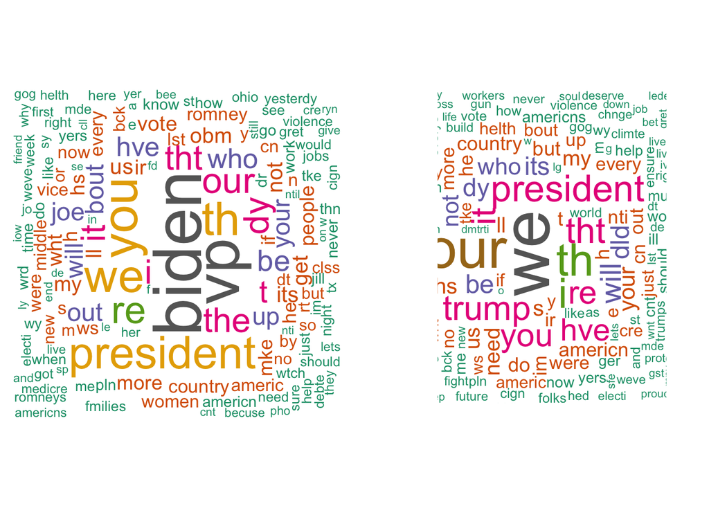

Figure 1: Wordcloud of most frequent word post (right) and pre (left) announcement

We observed that before running for presidency, the most frequent words that showed up in Biden’s tweets were “biden”, “president”, “you”, and “we”. After the announcement of running for presidency, the most frequent words changed to “Trump” and “our”, with“president” and “we” remained as highly frequent words. Considering that the tweets after running for presidency might contain more information related to his opponent Trump, It’s possible that the tweets after running for presidency became less positive.

### Method

The first lexicon method we used is **Bing** sentiment lexicon. The Bing lexicon helps us to categorize words in a binary fashion into positive and negative categories. We define the emotion intensity as the following: (the number of negative words + the number of positive words)/total word number in each post.

Next, we used the **Loughran-McDonald** sentiment lexicon, which is a English sentiment lexicon created for use with financial documents. This lexicon labels words with six possible sentiments important in financial contexts: “negative”, “positive”, “litigious”, “uncertainty”, “constraining”, or “superfluous”.

We also implement **NRC** EMOTION lexicon sentiment analysis. NRC Emotion Lexicon is a list of English words and their associations with eight basic emotions including “anger”, “fear”, “anticipation”, “trust”, “surprise”, “sadness”, “joy”, and “disgust.” In addition to the Bing method, this method explores more specific emotion within positive and negative sentiment.

To compare pre-announcement and post-announcement sentiment using each lexicon, we use **t-test** to see if the difference is significant. T-test is used to determine if there is a significant difference between the means of two groups. We used `unpaired` t test because we have larger sample size in post-announcement group.

We compare **proportions** of sentimental words in each tweet before and after announcement in plots and t-test because calculating the proportions instead of counting the numbers of sentimental words in each tweet would standardize the data.

### Result

#### Bing Sentiment Lexicon

##### Overall emotion intensity (proportion of emotional related word in each tweet)

```
##
##  Welch Two Sample t-test
##
## data:  likes$intensity_prop and likes_pre$intensity_prop
## t = -0.80785, df = 2428.3, p-value = 0.4193
## alternative hypothesis: true difference in means is not equal to 0
## 95 percent confidence interval:
##  -0.003682830  0.001533751
## sample estimates:
##  mean of x  mean of y
## 0.04147096 0.04254550
```

The p-value for overall emotion intensity is bigger than the significance level 0.05, therefore we fail to reject null hypothesis and conclude that there is no significant difference between overall emotion intensity before and after the announcement.

Next, we want to examine positive and negative sentiment word separately:

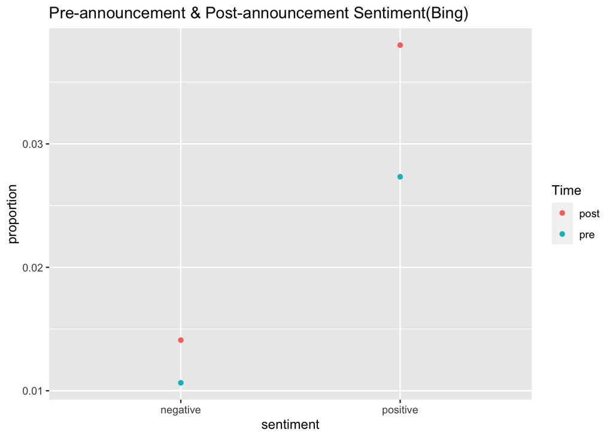

Figure 2: Pre-announcement & Post-announcement Sentiment(Bing)

From figure 2, we can see that the proportion of positive words in tweets after announcement largely increases, and the difference of proportions of negative words is much smaller. Therefore, we want to examine positive and negative emotion intensity separately using t-test.

##### Positive emotion intensity (proportion of emotional related word in each tweet)

```
##
##  Welch Two Sample t-test
##
## data:  likes$intensity_prop and likes_pre$intensity_prop
## t = 0.17801, df = 2571.7, p-value = 0.8587
## alternative hypothesis: true difference in means is not equal to 0
## 95 percent confidence interval:
##  -0.002002152  0.002401959
## sample estimates:
##  mean of x  mean of y
## 0.03078804 0.03058813
```

In contrast to the graph, the p-value of t test for positive emotion intensity is bigger than .05, which indicates that there is no significant difference between positive emotion intensity before and after the announcement.

##### Negative emotion intensity (proportion of emotional related word in each tweet)

```
##
##  Welch Two Sample t-test
##
## data:  likes$intensity_prop and likes_pre$intensity_prop
## t = -1.8343, df = 2115.5, p-value = 0.06675
## alternative hypothesis: true difference in means is not equal to 0
## 95 percent confidence interval:
##  -2.636999e-03  8.811259e-05
## sample estimates:
##  mean of x  mean of y
## 0.01068293 0.01195737
```

The same result also can be seen from t-test of negative emotion intensity: no significant difference between pre and post announcement proportion.

#### Loughran-Mcdonald Lexicon

We then analyze sentiment using the Loughran-Mcdonald Lexicon:

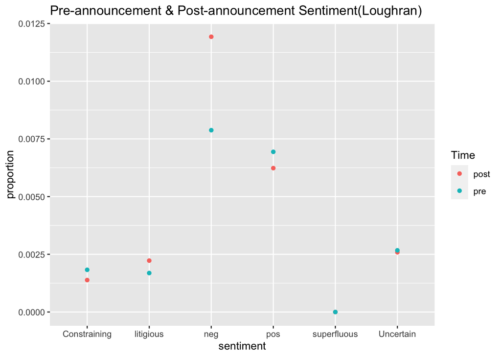

Figure 3: Pre-announcement & Post-announcement Sentiment(Loughran)

In figure 3, words with negative sentiment seem to show up more frequently in tweets after the announcement of running for presidency and there is a slight decrease in positive sentiment proportion after announcement. Although the result of positive and negative sentiment words is **consistent** with that of NRC lexicon in next section, we decide not to further analyze the difference using t-test because the Loughran lexicon was designed to analyze financial document sentiment, therefore the result might not be justifiable for this project.

#### NRC Lexicon

In this section, we used the NRC method, which has a more detailed and specific categorization of sentimental words.

```
##
##  Welch Two Sample t-test
##
## data:  data_nrc_pre$proportion and data_nrc_post$proportion
## t = 0.15153, df = 17.621, p-value = 0.8813
## alternative hypothesis: true difference in means is not equal to 0
## 95 percent confidence interval:
##  -0.01056883  0.01220922
## sample estimates:
##  mean of x  mean of y
## 0.01937072 0.01855052
```

We ran t-test on the overall sentiment proportions (include all kinds of sentiment) and found that there is no significant difference between the emotion intensity of tweets post-announcement and pre-announcement.

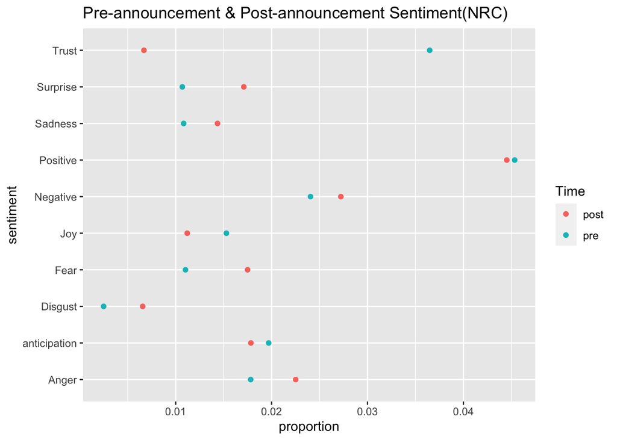

Figure 4: Pre-announcement & Post-announcement Sentiment(NRC)

In figure 4, words with negative sentiment including fear and anger seem to show up more frequently on tweets after the annoucement of running for presidency, while positive sentiment including joy and trust show up less frequently. We also noticed that the proportions of sentiment like Trust, Fear, and Disgust in each tweet before announcement seem to have an obvious difference with that of after announcement, therefore we ran unpaired t test and made a violin plot for each of the three sentiment.

##### Emotion: Trust

First, we looked at trust related word comparison. Since there is a huge difference between trust related words frequency before and after announcement, we’re curious to see what words are classified as trust-related:

```
##   [1] NA             "good"         "excited"      "president"    "rule"
##   [6] "vote"         "system"       "purely"       "rescue"       "policy"
##  [11] "sovereign"    "governor"     "successful"   "school"       "show"
##  [16] "rod"          "hope"         "hire"         "police"       "powerful"
##  [21] "volunteers"   "word"         "provide"      "trust"        "weigh"
##  [26] "grow"         "pledge"       "deserve"      "committed"    "fact"
##  [31] "experienced"  "credit"       "grit"         "mighty"       "supporter"
##  [36] "volunteer"    "proud"        "smile"        "friend"       "independence"
##  [41] "deputy"       "justice"      "friendly"     "budget"       "dignity"
##  [46] "expect"       "ground"       "voucher"      "cheer"        "level"
##  [51] "guide"        "fixed"        "united"       "dependent"    "found"
##  [56] "credible"     "elect"        "council"      "truth"        "effective"
##  [61] "respect"      "strength"     "top"          "secret"       "trophy"
##  [66] "enjoy"        "respects"     "count"        "labor"        "jury"
##  [71] "god"          "county"       "committee"    "sex"          "center"
##  [76] "green"        "generosity"   "rooted"       "improve"      "series"
##  [81] "serve"        "friendship"   "cover"        "promise"      "title"
##  [86] "succeed"      "institute"    "proven"       "present"      "worship"
##  [91] "humility"     "integrity"    "hero"         "freedom"      "inspired"
##  [96] "doubt"        "advice"       "neighbor"     "diligence"    "freely"
## [101] "recommend"    "goodness"     "true"         "fellow"       "food"
## [106] "assembly"     "believed"     "certify"      "worthy"       "resources"
```

Next, we implemented t-test and compare the proportion of trust-related word in violin plot:

```
##
##  Welch Two Sample t-test
##
## data:  trust_pre$trust_proportion and trust_post$trust_proportion
## t = 2.0947, df = 2229.5, p-value = 0.03631
## alternative hypothesis: true difference in means is not equal to 0
## 95 percent confidence interval:
##  0.000169313 0.005137185
## sample estimates:
##  mean of x  mean of y
## 0.02879419 0.02614094
```

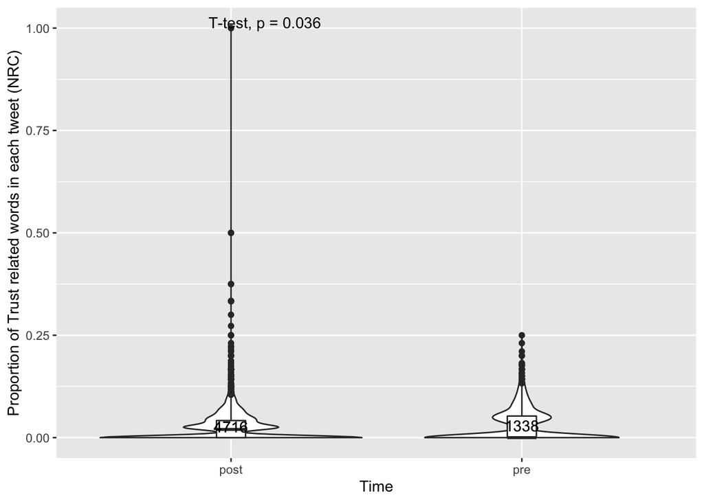

Figure 5: Proportion of Trust related words in each tweet (NRC)

##### Emotion: Fear

Next, we looked at fear-related word proportion:

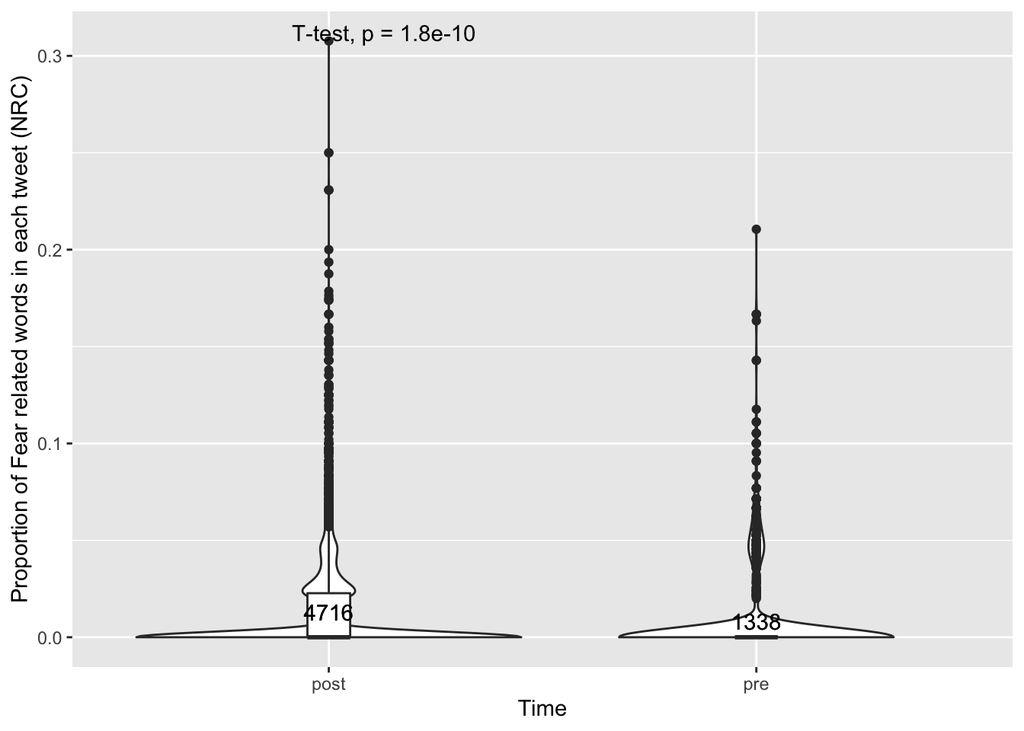

Figure 6: Proportion of Fear related words in each tweet (NRC)

```
##
##  Welch Two Sample t-test
##
## data:  fear_pre$fear_prop and fear_post$fear_prop
## t = -6.4048, df = 2405.6, p-value = 1.805e-10
## alternative hypothesis: true difference in means is not equal to 0
## 95 percent confidence interval:
##  -0.006074141 -0.003226568
## sample estimates:
##   mean of x   mean of y
## 0.008231192 0.012881546
```

##### Emotion: Disgust

We also explore disgust-related word proportion:

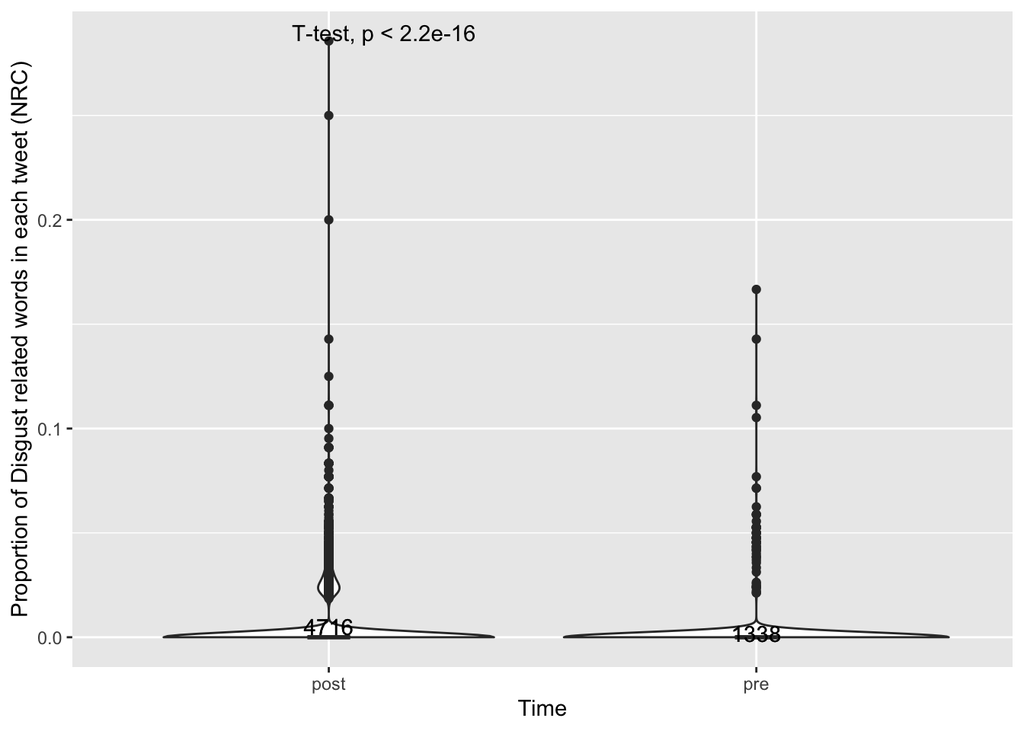

Figure 7: Proportion of Disgust related words in each tweet (NRC)

```
##
##  Welch Two Sample t-test
##
## data:  dis_pre$dis_prop and dis_post$dis_prop
## t = -8.3936, df = 2793.8, p-value < 2.2e-16
## alternative hypothesis: true difference in means is not equal to 0
## 95 percent confidence interval:
##  -0.003815931 -0.002370681
## sample estimates:
##   mean of x   mean of y
## 0.001872862 0.004966168
```

In figure 7, the differences of disgust-related words proportions of pre-announcement and post-announcement were not as obvious as the former two sentiment that we analyzed (Trust and Fear). But it’s still clear to see that the proportion of disgust related words in each tweet after announcement was higher than that of pre-announcement from p-value of t-test.

### Conclusion

In conclusion, we found that the emotional intensity proportion in general and both positive and negative does not differ significantly before and after announcement using the Bing lexicon method. However, some specific emotional related words such as trust, fear, disgust displayed a significant difference using the NRC lexicon analysis.

For limitations, our data is imbalanced with more tweets after announcement (4723 tweets) and less tweets before announcement (1341 tweets). Furthermore, we did analysis with Bing, Loughran-McDonald, and NRC lexicon; therefore, we were limited to words in those dictionary, and since emotional words show up very infrequently in tweets, our dataset is relatively sparse when conducting analysis. Lastly, the sentiment analysis were done on a word to word basis; therefore, the meaning and the context of the sentence could be ignored when each word is analyzed alone.

For future directions, we would like to explore the dataset further by adding time classifiers such as morning or afternoon tweets, so we could analyze the sentiment difference comparing tweets before and after announcement with accounts to time. Furthermore, our data is limited to Joe Biden’s personal account tweets from October 24th, 2007 to November 1st, 2020; therefore, we would like to get more recent tweets since November 1st, 2020 to conduct a more robust and conclusive analysis. Lastly, we would also like to combine current dataset with Joe Biden’s Presidential account @POTUS to see the overall sentiment change of Joe Biden.